# Plots

# Plotting who speaks

```r
my_play %>%
  select(docTitle) %>%
  distinct() %>%
  pull(1,1) -> my_title

my_play %>%
  select(year) %>%
  distinct() %>%
  pull(1,1) -> my_year

# Remember to count how many characters are on stage now
(my_summary %>%
  group_by(act_number, scene_number) %>%
  mutate(total = sum(n_distinct(speaker))) -> my_summary)
```

| act_number | scene_number | scene_index | speaker | boolean_spoke | total |
| --- | --- | --- | --- | --- | --- |
| 1 | 1 | 1 | troels | X | 1 |
| 1 | 2 | 2 | claus | X | 2 |
| 1 | 2 | 2 | troels | X | 2 |
| 1 | 3 | 3 | corfitz | X | 2 |
| 1 | 3 | 3 | troels | X | 2 |
| 1 | 4 | 4 | corfitz | X | 1 |
| 1 | 5 | 5 | jeronimus | X | 2 |
| 1 | 5 | 5 | corfitz | X | 2 |
| 1 | 6 | 6 | troels | X | 3 |
| 1 | 6 | 6 | corfitz | X | 3 |

[output cut: 107 more lines]

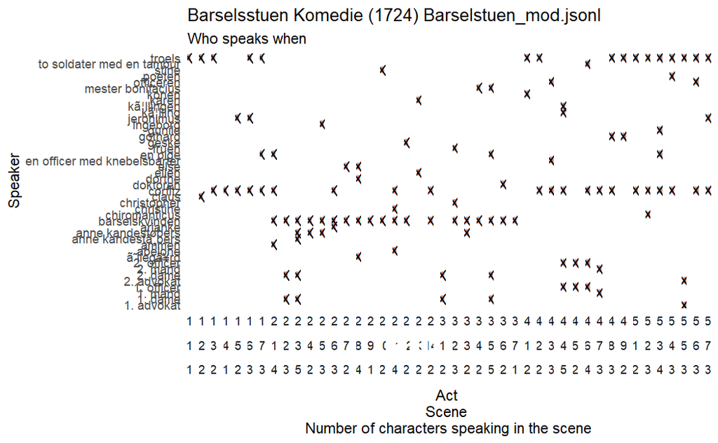

```r
# Let's plot it
my_summary %>%
  ggplot(aes(y = speaker, x = scene_index, width = 100)) +
    geom_tile(aes(fill = boolean_spoke, colour = speaker), colour = "grey", show.legend = FALSE) +
    geom_text(aes(label = "X")) +
    labs(
      title = paste(my_title, my_year, my_file),
      subtitle = "Who speaks when"
    ) +
  xlab("Act \nScene \nNumber of characters speaking in the scene") +
  ylab("Speaker") +
  theme(axis.text.x=element_blank(), line = element_blank(), rect = element_blank()) +
  facet_grid(cols = vars("act_number" = act_number, "scene_number" = scene_number, "total" = total), switch="x")

# And then we save the plot
  ggsave(here("graphs/plots", paste(my_file, ".hvem_taler_hvornaar.pdf")), width=16, height=9)
```

```r
NA
NA
```

# Plotting who is present

```r
# First, let's read in the play again
my_play <- read_play_jsonl(here("data", my_file))
# And find out who is present but does not speak
present_without_speech_numbers(my_play) %>%
  # Add a scene index for the x-axis
  rowwise() %>%
  mutate(scene_index = calc_scene_index(act_number, scene_number, act_length)) %>%
  # Add a boolean to denote who is present
    mutate(boolean_spoke = "S") %>%
  select(-index) -> present_silent
```

```
* `` -> ...4
```

```r
# Combine those who speak with those are present
my_summary %>%
    select(-total) %>%
  full_join(present_silent,
            by = c("speaker"="word", "act_number", "scene_number", "scene_index", "boolean_spoke")) -> new_summary

# Remember to count how many characters are on stage now
(new_summary %>%
  group_by(act_number, scene_number) %>%
  mutate(total = sum(n_distinct(speaker))) -> new_summary)
```

| act_number | scene_number | scene_index | speaker | boolean_spoke | total |
| --- | --- | --- | --- | --- | --- |
| 1 | 1 | 1 | troels | X | 1 |
| 1 | 2 | 2 | claus | X | 2 |
| 1 | 2 | 2 | troels | X | 2 |
| 1 | 3 | 3 | corfitz | X | 2 |
| 1 | 3 | 3 | troels | X | 2 |
| 1 | 4 | 4 | corfitz | X | 1 |
| 1 | 5 | 5 | jeronimus | X | 2 |
| 1 | 5 | 5 | corfitz | X | 2 |
| 1 | 6 | 6 | troels | X | 3 |
| 1 | 6 | 6 | corfitz | X | 3 |

[output cut: 123 more lines]

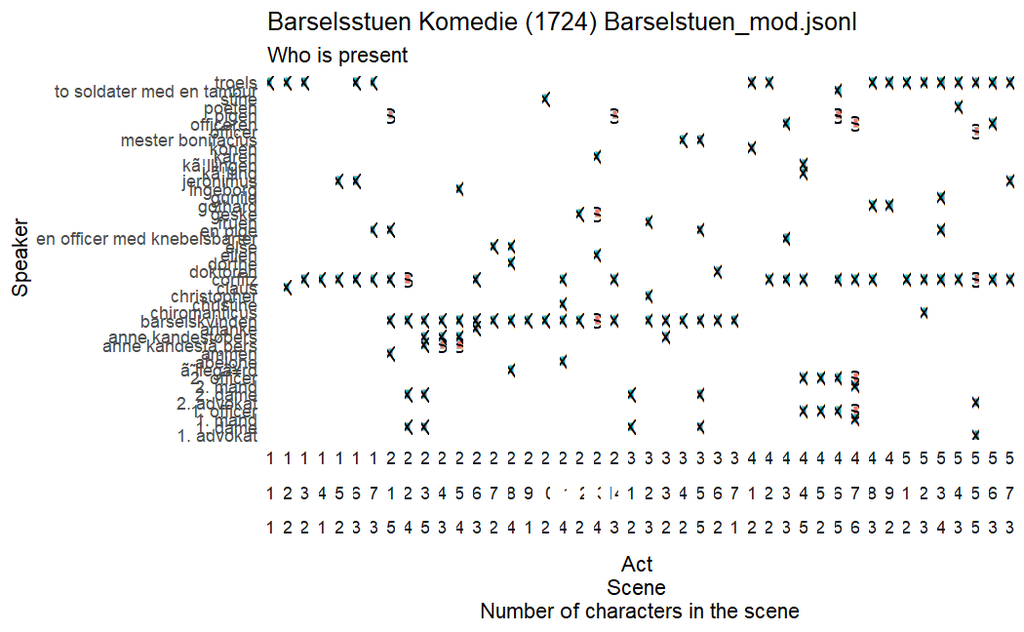

```r
new_summary %>%
  ggplot(aes(y = speaker, x = scene_index, width = 100)) +
    geom_tile(aes(fill = boolean_spoke, colour = speaker), colour = "grey", show.legend = FALSE) +
    geom_text(aes(label = boolean_spoke)) +
    labs(
      title = paste(my_title, my_year, my_file),
      subtitle = "Who is present"
    ) +
  xlab("Act \nScene \nNumber of characters in the scene") +
  ylab("Speaker") +
  theme(axis.text.x=element_blank(), line = element_blank(), rect = element_blank()) +
  facet_grid(cols = vars("act_number" = act_number, "scene_number" = scene_number, "total" = total), switch = "x")
```

```r
  #ggsave(here("graphs/plots", paste(my_file, ".hvem_til_stede.pdf")), width=16, height=9)
```

# Plotting who is spoken of

We want to know which characters are spoken of, even if they themselves are not present in the scene. First we need to define what we mean by being “spoken about”. We might find characters who are designated as “not present”, while being mentioned in the speech of another character. So if a character is mentioned while not being present in the scene, the character is “spoken about”.

Below we will find these characters and can add this data to the above plot.

```r
source(here("src", "omtale.R"))
(spoken_about(my_play) %>%
  # Add a scene index for the x-axis
  rowwise() %>%
  mutate(scene_index = calc_scene_index(act_number, scene_number, act_length)) %>%
  # Add a boolean for "spoken about"
    mutate(boolean_spoke = "O") %>%
  select(-index)
  -> spoken_about_summary)
```

```
* `` -> ...4
```

| act_number | scene_number | word | scene_index | boolean_spoke |
| --- | --- | --- | --- | --- |
| 1 | 1 | abelone | 1 | O |
| 1 | 1 | christine | 1 | O |
| 1 | 1 | christopher | 1 | O |
| 1 | 1 | ellen | 1 | O |
| 1 | 1 | geske | 1 | O |
| 1 | 1 | anne | 1 | O |
| 1 | 1 | ingeborg | 1 | O |
| 1 | 1 | dorthe | 1 | O |
| 1 | 1 | karen | 1 | O |
| 1 | 2 | ammen | 2 | O |

[output cut: 36 more lines]

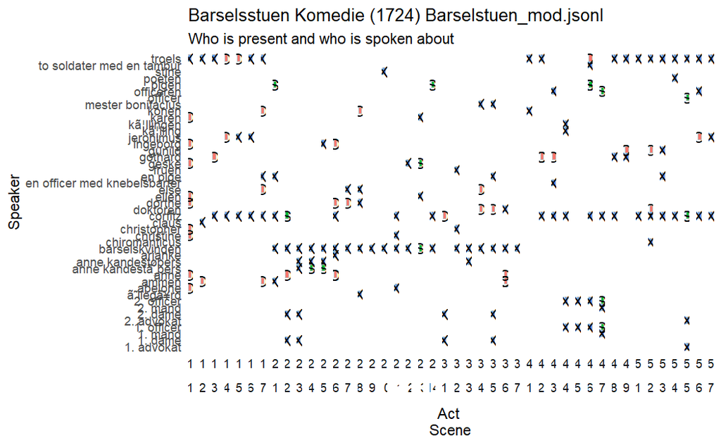

```r
new_summary %>%
    select(-total) %>%
  full_join(spoken_about_summary, by = c("speaker"="word", "act_number", "scene_number", "scene_index", "boolean_spoke")) %>%
  ggplot(aes(y = speaker, x = scene_index, width = 100)) +
    geom_tile(aes(fill = boolean_spoke, colour = speaker), colour = "grey", show.legend = FALSE) +
    geom_text(aes(label = boolean_spoke)) +
    labs(
      title = paste(my_title, my_year, my_file),
      subtitle = "Who is present and who is spoken about"
    ) +
  xlab("Act \nScene") +
  ylab("Speaker") +
  theme(axis.text.x=element_blank(), line = element_blank(), rect = element_blank()) +
  facet_grid(cols = vars("act_number" = act_number, "scene_number" = scene_number), switch = "x")
```

```r
  #ggsave(here("graphs/plots", paste(my_file, ".hvem_til_stede_hvem_omtalt.pdf")), width=16, height=9)
```